# A Look Into Tennessee Public Schools: In School Suspension Rate Analysis

## Lawand Yaseen

#### Date: 12/15/2021

#### Word Count: 2954

##### Introduction

With education reform occurring in a variety of ways since the start of the COVID-19 pandemic, I will be focusing on the potential impact that the recent passage of Tennessee Discipline Act will have on suspension rates in public schools. In particular, I will investigate the role that race, teacher expenditure, and school financing might have on suspension rates throughout the state. Collecting, processing and analyzing the data provided by the Tennessee Department of Education created missteps that required thorough reconfiguration while establishing some interesting trends that pointed to some unexpected relationships.In addition, this project exposed the intricate nature of discipline in the classroom and how predictors that incorporate school funding and resources can be indicative of a larger picture of underserved communities.

##### Problem Statement and Background

On April 6, 2021, the Governor of Tennessee, Bill Lee, signed into law the Teacher Discipline Act.$^1$ In short, the contents of the TDA allowed for public school K-12 teachers to begin the process of disciplining students and removing them from the classroom. This deviated from the existing statutes that required teachers to refer students to principals but ultimately kept the process initiation of punishing students in the hands of principals. The traditional forms of removal from the classroom in Tennessee are the following: in-school suspension (ISS), out of school suspension (OSS), expulsion and placement in an alternative school. Under the law prior to the enforcement of the TDA, principals had complete control over the use of any of these disciplines.$^1$ However, the TDA applied directly to a teacher’s ability to enforce an ISS. In the eyes of many, this passage would “give teachers more control over their classroom and ensure all students have a safe, productive learning environment.”$^2$

Behavioral punishment in the classroom has long been a point of research and concern among education equity advocates as a vital stepping stone in the “school to prison pipeline.” This terminology reflects the role that classroom punishment and interactions with the law as a juvenile is correlated with falling into the criminal justice system. Particularly, it has been documented that students of color and students with disabilities are more likely to incur any of the aforementioned disciplinary options. They are also more likely to experience punitive discipline.$^3$ Nationwide, the APA reports that “students were four times more likely to be arrested than a student that had not received a suspension.”$^3$ Specifically in Tennessee, ProPublica, as part of their “Miseducation” series, conducted research that analyzed suspension and education outcomes by race. They found that black students in Tennessee were nearly 5 times more likely to be suspended than white students.$^4$ Unfortunately, their updates ceased after 2018.$^4$ The goal of this project and following analysis is to investigate the relationship that race, teacher experience or per student expenditure can have on ISS rates in the state of Tennessee.

##### Data

In order to complete this project, suspension, enrollment and financing data at the school level would be required to be collected. Fortunately, all of the aforementioned content was publicly available from the Tennessee Department of Education.$^5$ As the data for 2019 to 2020 was incomplete due to the COVID-19 data, the most recent data was for the 2018-2019 school year. Within the “Data Downloads and Requests” page, the following spreadsheets were downloaded for use: *Membership, Discipline, Educator Experience and Final Report Card.*$^5$ As previously mentioned, the data within each spreadsheet was listed at the school level with columns identifying race, teacher experience and spending metrics.

While the data could have been aggregated up to the district level, I chose to keep my unit of observation at the school level. This would provide me with more options for the machine learning aspect of this project. Jumping ahead, the amount of data at the district level would’ve been approximately 120 while the school level analysis I performed had over 800 schools as part of the final dataset. For the outcome of interest, I used ISS rates that were found in the *Discipline* spreadsheet. It was reported as a percentage of the students who were suspended from the subpopulation of interest. In this case, I finalized the use of the “All Students” student group which simply was the ISS rate for the entire school, regardless of identifying content.

As previously discussed, the set of predictor variables I was most interested in was the racial and gender makeup of each school. Within the *Membership* spreadsheet, the following demographic groups were included: **Female, Male, Native, Asian, Black, Hispanic, AAPI, White and multiple ethnicities**. The number of students at each school who fell into each category was transformed and linked to the suspension dataframe. In a similar vein, the percentage of inexperienced teachers, which was included in the *Educator Experience* spreadsheet was pulled into the data as another predictor of ISS rates. Lastly, the per student spending at the school level was included from the *Final Report Card* spreadsheet.

Early on in the analysis, I used the suspension rates that were provided at demographic and the student’s economic status level as the primary set of predictor variables. At first, this seemed logical but as I began to look into the potential for relationships, I recognized that these were causing bias to occur in the model. As the ISS rate increased among any of the student subcategories, the ISS rate would always increase. For example, a white student who was suspended would be included in the white subset and the outcome data. From there onwards, I reverted to using the enrollment data that was found in the *Membership* spreadsheet. To best capture this information, I took the number of students in each population and divided it by the total student population at each school, yielding the percentage of students who identify for a given race. In addition, while creating the initial visualizations, which were shown in the video presentation, I noticed that elementary schools almost always had a ISS rate of 0. This has the potential of skewing the results to both be more accurate. Also, it must be noted that students who are suspended or expelled for criminal offenses at the middle and high school levels are more likely to be referred to the criminal justice system as a juvenile. For these reasons, I chose to drop the elementary schools that were initially included.

##### Analysis

After downloading the raw data from the available databases provided by the TN DoE, I first acknowledged that the ISS data was presented as a percentage of the student population. This applied not only to the outcome of interest but also to various measurements of ISS that they included. For example, within the *Discipline* file, each school had the percentage of White, Black, Asian, and economically disadvantaged students who were suspended. My initial thought was to use these reported values as my content for the predictive variables within my model. At first glance, this seemed reasonable. In addition, when using these predictors in the model I chose, shown later on, the error in prediction was relatively low. While these are the kinds of effects I’d hope for, after taking a step back from the data, I came to the conclusion that using those race ISS rates as predictors was inherently flawed. By using these predictors, I was incorporating multicollinear predictors, where an inclusion of these values meant that any change in each group would directly affect the value of the total suspension rate. For example, at a majority white school, if the total suspension rate as well as the suspension rate among white students was high, then it would not be valid to assume that race was a factor in the rate of ISS enforcement. To compensate for this issue, I chose to use the enrollment data from Measurement which provided the number of students at each school as well as the racial makeup. While I previously discussed the implication of this usage, I chose to take the percentage of each race at each school to scale these values between 0-100, instead of ranging based on the size of each school. In order to ensure that the data for each predictor variable corresponded to the school that it was reported for, I pulled a unique list of each school that was in the Discipline data set while removing the “All Schools” data. This step and all of the forthcoming steps were done using the pandas package. From there, I filtered the original dataframe, removing any instances where the school corresponding to a particular observation was not in the list. In addition, I excluded all schools that included the word “Elementary” in its name. That reduced the size of the school list from 1691 to 840. From there, I only selected the columns that included the school name and the overall ISS suspension rates, giving me my cleaned up outcome of interest. To collect the predictor variables in a way that would be conducive to completing the project, I used that unique list to perform the same action of removing any excess school observations. Then, I created a list of the unique instances of race observed in the dataset which were: “American Indian or Alaskan Native”, “Asian”, “Black or African American”, “Hispanic”, “Native Hawaiian or Pacific Islander”, “White”. For each of these instances, I collected the number of students at each school and merged each corresponding column based on the column that held the school name. In addition to these predictor variables, I collected the percentage of inexperienced teachers at each school from the Educator Experience dataset, only collecting the schools of interest that were already in the dataset that I have been constructing. I avoided using any other educator metric from this dataset because the teacher experience data was binary - experienced teachers would be the complement to the inexperienced teachers. Lastly, I collected the per student funding, which was similarly constructed and required the same format of cleaning. As not all of the schools were found in every dataset, the final number of schools with a full array was 819, down from the 840 unique middle and high schools found from cleaning the Discipline dataset.

The first of three visualizations I aimed to produce from the data which I believe encapsulates the investigations I was most interested in. First, I wanted to take the three major race groups in the state, White, Hispanic, and Black, into a scatterplot that compared the percentage of the population as a function of the ISS rate. That would be done by adding each of their enrollment percentages at each school, for each race category, compared to the ISS rate for each school, with a legend to mark the different races. The second of the three visualizations I worked to generate was an analysis of the effect of teacher experience on suspension rate. To do so, I created a scatterplot with the ISS rate as a function of teacher experience using the inexperience data. In addition to this plot, I added a linear regression to determine if there was any potential relationship between the two. Lastly, I generated a tile plot that examined if a lack of funding at the student level had a common impact on the ISS rate. Initially, I used a pandas feature to assign the per student spending column quartiles and assigned dummy variables indicating which quartile each school fell into. From there, I subset the data to include the 25 schools with the highest ISS rate to help draw conclusions.

Prior to determining which model to use, I split my existing data set into two groups: training and test. To create the split, I used SK Learn’s train_test_split to create a training dataset that was 80% of the original dataset while the test dataset was the remaining 20%, without replacement. To build the machine learning model for this dataset, I evaluated the methodology that we have been introduced to throughout this semester. As my outcome of interest is a continuous variable, there were limited options to work with. Had my outcome of interest been a dichotomous variable, I would’ve had the potential to use a classifier to observe the probability of predicting an outcome given a certain set of inputs. So, to efficiently examine all of the models effectiveness at predicting the outcome of interest, I employed the use of the SK Learn API to evaluate the following algorithms: Linear Regression, K-Nearest Neighbors, Decision Trees, Bagging and Random Forest. Each of these algorithms are equipped to predict the outcome using their unique methodology and can indicate the algorithm with the least amount of mean squared error using cross validation. To test the efficiency of each algorithm, I used the training dataset. The outcome of interest of ISS rate was subset from the other entries in the dataset. On the other hand, the predictor variables I chose to include in the process were the following: **Female, Male, Native, Asian, Black, Hispanic, Multiple, AAPI, White, Teacher Experience, and Per Student Spending**. After determining the most effective algorithm, I used the test data to predict a set of outcomes and compare those predicted values to the true values. In order to evaluate the level of impact that each of these predictors had on the most efficient model’s accuracy, I continued to use SK Learn which also had a permutation importance algorithm which I used to evaluate, which essentially shows how much the model decreases when a variable is changed at random. From there, I also worked to include a visualization to show the impact. From these two analyses, I hoped to show any potential impact that race may have on the accuracy of predicting ISS rates at the school level.

##### Results

In the *Fig.1* below, the ISS rate is shown as a function of the percentage of White, Hispanic and Black students. White students are represented using red dots, Black students represented using black dots and lastly, Hispanic students represented using blue dots. From this graph, there are no clear patterns of discrimination across the state among school’s with varying enrollment makeup. It must be noted that white students often made the majority of students, which closely represents the state’s racial breakdown. Schools with relatively high ISS rates did not have a particular race in common.

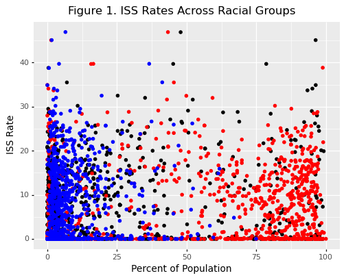

Next, I investigated the potential relationship between teacher inexperience and ISS rates. As shown in figure 2, there was a slightly negative correlation between having inexperienced teachers and the ISS rate. I found this to be interesting as the expectation is that inexperienced teachers are more likely to have issues with controlling their classroom, leading to the need for disciplinary action to bring order. From Figure 2, we can approximate that the average suspension rate for a school with a teacher inexperience level of 0% to be approximately 10%. The prediction interval of this regression line loses accuracy as the teacher inexperience level increases.

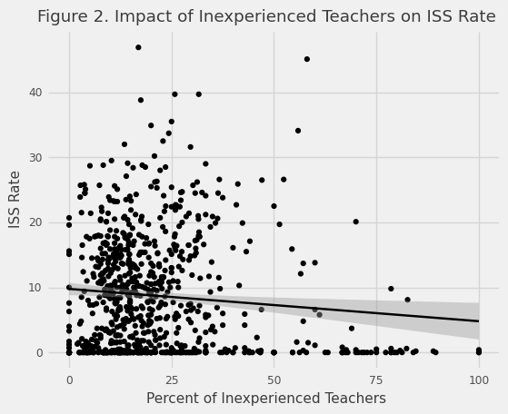

Lastly, Figure 3 compares the spending levels among the 25 schools with the highest ISS rates. Among these schools, very few of them were in the bottom quartile of spending. On the other hand, it was more common to be among the middle quartiles of spending, pointing to the relative lack of impact per student spending may have on the extreme cases of ISS rates. In addition, there were more schools that were classified as the top spenders per student than there were in the bottom quartile.

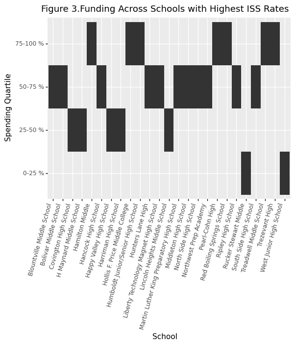

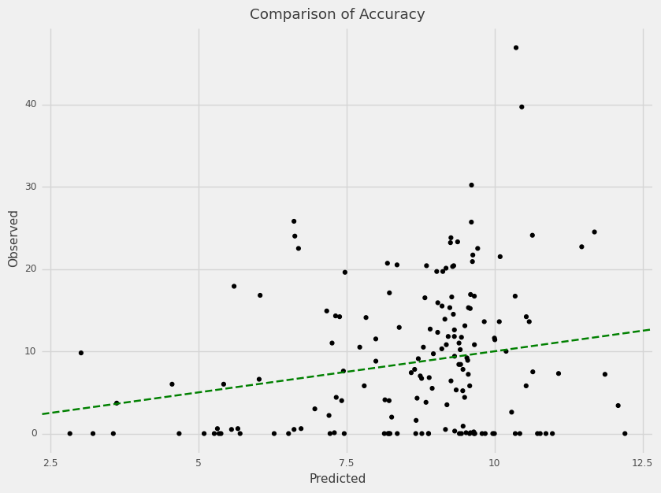

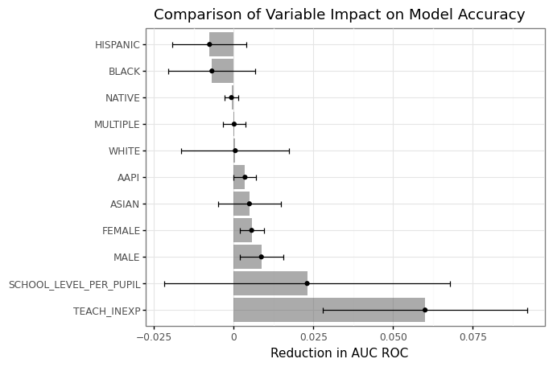

##### Discussion

Overall, this investigation into predicting ISS rates at the school level using race yielded some very interesting results and frankly went against some of the preconceived notions I had about the expected results. Particularly, I found it extremely difficult to draw conclusions based off the racial makeup at the school level about ISS rates that would lead me to state that race played a large factor in suspension. In addition, it seems as though the variables that I included just as controls, teaching experience and per student spending, had more of an impact on predicting ISS rates. In terms of the goals that I sought out to accomplish, I had a mixed bag of results compared to the expectations I outlined. Notably, I was unable to create the map of Tennessee with the density of suspension rates for each school. My initial plan was to create a crosswalk between what school district each school was assigned to and the county geographical coordinates to graph. However, that would’ve required aggregating the data upwards to the county level which would’ve severely limited my ability to use the data for machine learning. While my model indicated that teacher experience was the biggest predictor, if this holds true in a future analysis, that would hold serious implications in policy implementation of the TDA. As shown in Fig. 4 and permutation importance indicated in Fig. 5, if teacher inexperience is a true predictor, then we will see an increased amount of suspensions occurring now that the process has become more simplified for teacher’s to take action. In the future, I would like to explore the relationship between enrollment racial makeup and the ISS rates for each of these groups, rather than the school’s overall ISS rate.

##### Citations

1. https://tn.chalkbeat.org/2021/2/24/22300159/tennessee-discipline-bill-raises-concerns-about-potential-bias-against-black-or-disabled-students
2. https://apnews.com/article/bills-legislation-tennessee-13faf86d39dc159b20b90135712f9714
3. American Pyschological Association, "The Pathway from Exclusionary Discipline to the School to Prison Pipeline"
4. https://projects.propublica.org/miseducation/state/TN
5. https://www.tn.gov/education/data/data-downloads.html